# RM 8.5 Random Forest — Lead-Aware Predictor Reliance (7DADM)

Maddee Wiggins (FlowWest)

2026-08-06

# 1. Objective

RM 8.5’s own previous-day 7DADM (`dadm_m1`) is a natural candidate predictor: water temperature changes gradually, so yesterday’s reading is genuinely informative about tomorrow’s. But that informativeness should decay with forecast horizon — by 7 days out, `dadm_m1` reflects conditions a full week stale, while the NWS forecast for the target date actually describes what’s coming. A model that keeps leaning on `dadm_m1` just as heavily at lead 7 as at lead 1 is behaving like a persistence forecast dressed up as a multi-day prediction, and should be expected to perform worse on genuinely novel weather than its lead-1 counterpart would suggest.

# 2. Predictor Design

Four groups of predictors are used, each included for a specific reason:

[output not shown]

## 2.1 Every predictor must reflect what’s actually known at forecast time

A forecast issued on a given **run date** for a target `lead_k` days later can only use information available as of that run date — never information from between the run date and the target date. Concretely: `dadm_m1` for a lead-7 forecast must be RM 8.5’s reading from `run date − 1`, not from `target date − 1` (which is 6 days *after* the run date). The same applies to Camp Polk’s current conditions and trend.

This is enforced by building every “current” and “lagged” predictor via an explicit date-shifted join against the target date, rather than a row-position-based lag — the latter silently drifts from “run-date-relative” to “target-date-relative” as `lead_k` grows, which would let longer-lead models see information they wouldn’t actually have yet. Getting this wrong would inflate longer-lead performance in exactly the way this analysis is trying to measure honestly.

## 2.2 Train/test split is chronological, not random

Water temperature is a strongly autocorrelated daily series. A random train/test split places days adjacent to each other on opposite sides of the split, letting the model implicitly see near-neighbors of its test points during training — this inflates apparent accuracy without reflecting real forecast skill. The last 20% of dates are held out as test; the model never sees them, or anything derived from them, during training.

```r
month_start     <- 5
month_end       <- 10
lead_days_vec   <- c(1:7)

ntree           <- 500
test_frac       <- 0.20   # chronological holdout
trend_window    <- 5      # days spanned by the Camp Polk trend features
threshold_7dadm <- 20.0   # HCP action threshold, same as run-daily-forecast.R

# Shared color scale for lead_days plots below (blue = short lead, red = long lead)
lead_colors <- setNames(colorRampPalette(c("#185FA5", "#4E9F50", "#C93312"))(length(lead_days_vec)),
                        as.character(lead_days_vec))
```

# 3. Data & Feature Construction

```r
rm85_7dadm <- rm_8_5_historical |>
  mutate(date = as.Date(date)) |>
  filter(statistic == "7DADM") |>
  select(date, rm_8_5_7dadm = temperature)

cp_7dadm <- camp_polk_temperature_historical |>
  mutate(date = as.Date(date)) |>
  filter(statistic == "7DADM") |>
  select(date, cp_7dadm = temperature)

cp_flow <- camp_polk_flow_historical |>
  mutate(date = as.Date(date)) |>
  filter(statistic == "mean") |>
  select(date, cp_flow_mean = flow_cfs)
```

```r
# NWS air temperature/cloud cover at a given lead. `all_historical_forecasts`
# is a best-estimate stitched series rather than a true archived multi-lead
# forecast product, so this is a proxy — falls back to observed weather
# (lead_days == 0) wherever a lead-specific value is missing.
get_forecast <- function(lead_k) {
  fcst <- all_historical_forecasts |>
    filter(lead_days == lead_k) |>
    select(valid_date, variable, value) |>
    pivot_wider(names_from = variable, values_from = value) |>
    rename(date = valid_date, air_max = temperature_2m_max,
           air_min = temperature_2m_min, cloud_pct = cloud_cover_mean)

  obs <- all_historical_forecasts |>
    filter(lead_days == 0) |>
    select(valid_date, variable, value) |>
    pivot_wider(names_from = variable, values_from = value) |>
    rename(date = valid_date, air_max = temperature_2m_max,
           air_min = temperature_2m_min, cloud_pct = cloud_cover_mean)

  bind_rows(fcst, obs) |> distinct(date, .keep_all = TRUE)
}

# Full available NWS trajectory (lead 1-7), reshaped from "one row per
# target date" to "one row per run date". A lead-k model only keeps columns
# d1..dk here — dk always lands exactly on the target date (run_date + k =
# target date), so d(k+1) onward would be *after* the target: real weather
# a real forecast wouldn't need to answer that specific horizon, and not
# something every lead should see identically regardless of its own k.
#
# Each day also carries its own julian_dN — the day-of-year of THAT specific
# calendar date (run_date + N), not just the target date's. A single Julian
# for the target date leaves the model to infer each trajectory day's season
# indirectly (via target Julian + column identity); pairing Julian directly
# with the day it describes tested measurably better at longer leads, where
# the trajectory spans enough days for that seasonal offset to matter.
get_forecast_trajectory <- function(lead_k) {
  offsets <- seq_len(lead_k)
  day_tables <- map(offsets, function(k) {
    get_forecast(k) |>
      mutate(run_date = date - k) |>
      transmute(
        run_date,
        !!paste0("air_max_d", k) := air_max,
        !!paste0("air_min_d", k) := air_min,
        !!paste0("cloud_d",   k) := cloud_pct,
        !!paste0("julian_d",  k) := yday(date)
      )
  })
  reduce(day_tables, full_join, by = "run_date") |> arrange(run_date)
}

# Builds one row per target date. Camp Polk's current values, its trend
# features, and dadm_m1 are all constructed via explicit run-date-relative
# joins (target date - lead_k [- 1 or - trend_window, as appropriate]) per
# Sect. 2.1.
build_df <- function(lead_k) {
  fcst_traj <- get_forecast_trajectory(lead_k) |>
    mutate(date = run_date + lead_k) |>
    select(-run_date)

  cp_flow_run  <- cp_flow  |> mutate(date = date + lead_k)
  cp_7dadm_run <- cp_7dadm |> mutate(date = date + lead_k)

  cp_flow_m1_tbl  <- cp_flow  |> mutate(date = date + lead_k + 1) |> rename(cp_flow_m1 = cp_flow_mean)
  cp_flow_mw_tbl  <- cp_flow  |> mutate(date = date + lead_k + trend_window) |> rename(cp_flow_mw = cp_flow_mean)
  cp_7dadm_m1_tbl <- cp_7dadm |> mutate(date = date + lead_k + 1) |> rename(cp_7dadm_m1 = cp_7dadm)
  cp_7dadm_mw_tbl <- cp_7dadm |> mutate(date = date + lead_k + trend_window) |> rename(cp_7dadm_mw = cp_7dadm)

  dadm_m1_tbl <- rm85_7dadm |>
    mutate(date = date + lead_k + 1) |>
    rename(dadm_m1 = rm_8_5_7dadm)

  rm85_7dadm |>
    left_join(cp_flow_run,      by = "date") |>
    left_join(cp_7dadm_run,     by = "date") |>
    left_join(fcst_traj,        by = "date") |>
    left_join(cp_flow_m1_tbl,   by = "date") |>
    left_join(cp_flow_mw_tbl,   by = "date") |>
    left_join(cp_7dadm_m1_tbl,  by = "date") |>
    left_join(cp_7dadm_mw_tbl,  by = "date") |>
    left_join(dadm_m1_tbl,      by = "date") |>
    mutate(
      cp_flow_trend  = (cp_flow_m1  - cp_flow_mw)  / (trend_window - 1),
      cp_7dadm_trend = (cp_7dadm_m1 - cp_7dadm_mw) / (trend_window - 1),
      month  = month(date)
      # No standalone Julian: julian_dk (from fcst_traj) already covers the
      # target date's own day-of-year, and julian_d1..d(k-1) cover the rest
      # of the trajectory the single value used to miss.
    ) |>
    filter(month >= month_start, month <= month_end) |>
    drop_na() |>
    distinct(date, .keep_all = TRUE) |>
    arrange(date)
}

# Feature set is itself a function of lead_k now, since the trajectory only
# spans d1..dk (see get_forecast_trajectory()) — including julian_d1..dk in
# place of a single target-date Julian.
get_weather_features <- function(lead_k) {
  c("cp_flow_mean", "cp_7dadm", "cp_flow_trend", "cp_7dadm_trend",
    paste0("air_max_d", 1:lead_k), paste0("air_min_d", 1:lead_k),
    paste0("cloud_d", 1:lead_k), paste0("julian_d", 1:lead_k))
}
get_persistence_features <- function(lead_k) c(get_weather_features(lead_k), "dadm_m1")

split_chronological <- function(df, p = test_frac) {
  df <- df |> arrange(date)
  n  <- nrow(df)
  n_test <- floor(n * p)
  list(
    train = df[seq_len(n - n_test), ],
    test  = df[seq(n - n_test + 1, n), ]
  )
}

fit_rf <- function(train_df, features, target = "rm_8_5_7dadm", seed = 42) {
  set.seed(seed)
  randomForest(
    formula = as.formula(paste(target, "~", paste(features, collapse = " + "))),
    data    = train_df[, c(features, target)],
    ntree   = ntree,
    mtry    = max(1, floor(length(features) / 3)),
    importance = TRUE
  )
}

rmse <- function(pred, obs) sqrt(mean((pred - obs)^2))
```

# 5.One Random Forest per Lead

```r
lead_results <- map(lead_days_vec, function(k) {
  df     <- build_df(k)
  splits <- split_chronological(df)
  model  <- fit_rf(splits$train, get_persistence_features(k))
  pred   <- predict(model, splits$test)
  obs    <- splits$test$rm_8_5_7dadm

  list(
    lead = k, model = model,
    test_dates = splits$test$date, test_obs = obs, test_pred = pred,
    RMSE = rmse(pred, obs),
    MAE  = mean(abs(pred - obs)),
    R2   = 1 - sum((pred - obs)^2) / sum((obs - mean(obs))^2),
    n_train = nrow(splits$train), n_test = nrow(splits$test)
  )
})
names(lead_results) <- paste0("lead_", lead_days_vec)
```

## 5.1 Test performance by lead

```r
results_table <- map_dfr(lead_results, ~ tibble(
  lead = .x$lead, n_train = .x$n_train, n_test = .x$n_test,
  RMSE = .x$RMSE, MAE = .x$MAE, R2 = .x$R2
))
knitr::kable(results_table, digits = 3,
             col.names = c("Lead (days)", "n train", "n test", "RMSE (°C)", "MAE (°C)", "R²"))
```

| Lead (days) | n train | n test | RMSE (°C) | MAE (°C) | R² |
| --- | --- | --- | --- | --- | --- |
| 1 | 1756 | 438 | 0.873 | 0.656 | 0.945 |
| 2 | 1756 | 438 | 1.014 | 0.797 | 0.927 |
| 3 | 1756 | 438 | 1.145 | 0.916 | 0.908 |
| 4 | 1756 | 438 | 1.251 | 1.006 | 0.891 |
| 5 | 1756 | 438 | 1.354 | 1.089 | 0.874 |
| 6 | 1756 | 438 | 1.448 | 1.167 | 0.857 |
| 7 | 1756 | 438 | 1.525 | 1.226 | 0.843 |

Performance degrades steadily with lead, as it should for a genuine forecast: longer horizons carry more real uncertainty, and this design doesn’t disguise that with information it shouldn’t have.

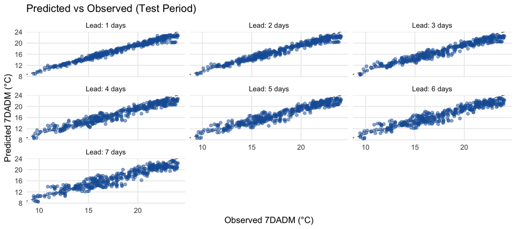

```r
map_dfr(lead_results, ~ tibble(lead = .x$lead, observed = .x$test_obs, predicted = .x$test_pred)) |>
  ggplot(aes(x = observed, y = predicted)) +
  geom_abline(slope = 1, intercept = 0, linetype = "dashed", color = "#666666") +
  geom_point(alpha = 0.5, color = "#185FA5", size = 1.5) +
  facet_wrap(~paste("Lead:", lead, "days")) +
  labs(title = "Predicted vs Observed (Test Period)",
       x = "Observed 7DADM (°C)", y = "Predicted 7DADM (°C)") +
  theme_minimal() +
  theme(panel.grid.minor = element_blank())
```

## 5.2 Forecast vs. observed over time

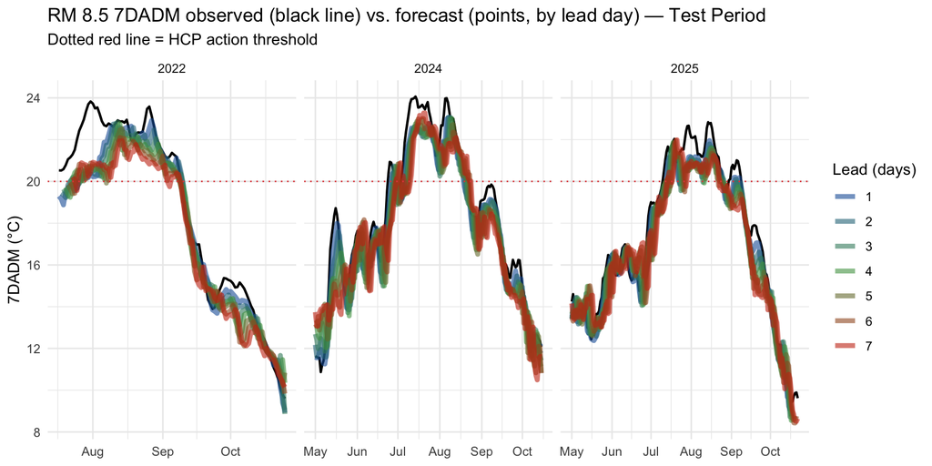

```r
test_long <- map_dfr(lead_results, ~ tibble(
  lead = .x$lead, date = .x$test_dates, observed = .x$test_obs, predicted = .x$test_pred
))

# Observed is the same physical series regardless of lead — collapse to one
# row per date before drawing the line, since different leads' test sets can
# differ slightly at the edges depending on which rows survived drop_na().
observed_7dadm <- test_long |> distinct(date, observed) |> arrange(date)

ggplot() +
  geom_line(data = observed_7dadm, aes(x = date, y = observed), color = "black", linewidth = 0.8) +
  geom_line(data = test_long, aes(x = date, y = predicted, color = factor(lead)), size = 1.6, alpha = 0.6) +
  geom_hline(yintercept = threshold_7dadm, linetype = "dotted", color = "#E24B4A") +
  facet_wrap(~year(date), scales = "free_x") +
  scale_color_manual(values = lead_colors) +
  labs(
    title = "RM 8.5 7DADM observed (black line) vs. forecast (points, by lead day) — Test Period",
    subtitle = "Dotted red line = HCP action threshold",
    x = NULL, y = "7DADM (°C)", color = "Lead (days)"
  ) +
  theme_minimal()
```